# Working with dates using `lubridate`

Author

Casey Schine adapted from Emily Malcolm-White

Dates and times are everywhere in data: timestamps on social media posts, transaction dates in sales records, birthdates in survey data. But unlike numbers or strings, dates are tricky—you can’t just subtract them like normal numbers, and parsing them from messy formats can be a headache.

# Date Formats

Yikes!

# Date, Time, and Datetime

Date/time data are data that conveys information about, you guessed it, date and/or time! There are three relevant data types when we talk about date/time data:

1. Date - only has the date (e.g. 2020-05-15)
2. Time - only has the time (e.g. 20:45:00)
3. Datetime - has both the date and time (e.g. 2020-05-15 20:45:00)

# `Lubridate`

```r
#LOAD PACKAGES
library(tidyverse) #lubridate is in the tidyverse!
```

# Standard Date Format

The `ymd()` function transforms data in all kinds of different formats into a standardized date format displaying year, then month, then day.

```r
# all of the different date formats that you can use with ymd

# "06 02 04"
# "06/02/04"
# "20060204"
#" 2006 2 4"
# 060204

ymd("2026-4-14")
```

```
[1] "2026-04-14"
```

```r
ymd(20260414)
```

```
[1] "2026-04-14"
```

```r
ymd("2026/4/14")
```

```
[1] "2026-04-14"
```

`mdy()` (month day year) and `dmy()` (day month year) formats also exist for dates.

```r
# an example with mdy()
mdy(04142026)
```

```
[1] "2026-04-14"
```

```r
# an example with dmy()

dmy(14042026)
```

```
[1] "2026-04-14"
```

`ymd_hms()` helps to format datetimes.

```r
# ymd_hms() with "2020-04-01 10:30:13"

ymd_hms("2020-04-01 10:30:13")
```

```
[1] "2020-04-01 10:30:13 UTC"
```

```r
# now with "2020/04/01 10.30"
ymd_hm("2020/04/01 10.30")
```

```
[1] "2020-04-01 10:30:00 UTC"
```

# Extracting Components

Once you have a date object, you can easily extract parts of it:

```r
birthday <- ymd("1983-04-14")

class(birthday)
```

```
[1] "Date"
```

```r
# extract year using year()

year(birthday)
```

```
[1] 1983
```

```r
# extract month using month()
month(birthday)
```

```
[1] 4
```

```r
# set label=TRUE to get the month name instead of number
month(birthday, label=TRUE)
```

```
[1] Apr
12 Levels: Jan < Feb < Mar < Apr < May < Jun < Jul < Aug < Sep < ... < Dec
```

```r
# extract day using day()

day(birthday)
```

```
[1] 14
```

```r
# want to know what day of the week??? use wday() with label=TRUE

wday(birthday, label=TRUE)
```

```
[1] Thu
Levels: Sun < Mon < Tue < Wed < Thu < Fri < Sat
```

# Doing Math with Dates

Set up the object `today` as today’s date:

```r
today <- Sys.Date()
```

Calculate the age based on today’s date and your birthday. This is possible when both are in date or datetime formats. You can also use the function `difftime()` if you want to specify the units.

```r
#calc time beween today and birthday using simple subtraction

today-birthday
```

```
Time difference of 15706 days
```

```r
# calc time between birthday and today using difftime()

difftime(today, birthday, units="mins")
```

```
Time difference of 22616640 mins
```

```r
difftime(today, birthday, units="hours")
```

```
Time difference of 376944 hours
```

What will be the date 28 days from now?

```r
# add 28 to today

today+28
```

```
[1] "2026-05-12"
```

# Portal Data

The Portal Project is a long-term ecological study being conducted near Portal, AZ. Since 1977, the site has been used to study the interactions among rodents, ants and plants and their respective responses to climate.

```r
#LOAD DATA
portal_rodent <- read.csv("https://github.com/weecology/PortalData/raw/main/Rodents/Portal_rodent.csv")
```

```r
# take a look at the data and how date/time are in the data

# use make_date() to turn these into a new column with datetime

portal_rodent_mod <- portal_rodent |>
  mutate(date=make_date(year, month, day))
```

A line plot showing the number of rodents captured per day over time:

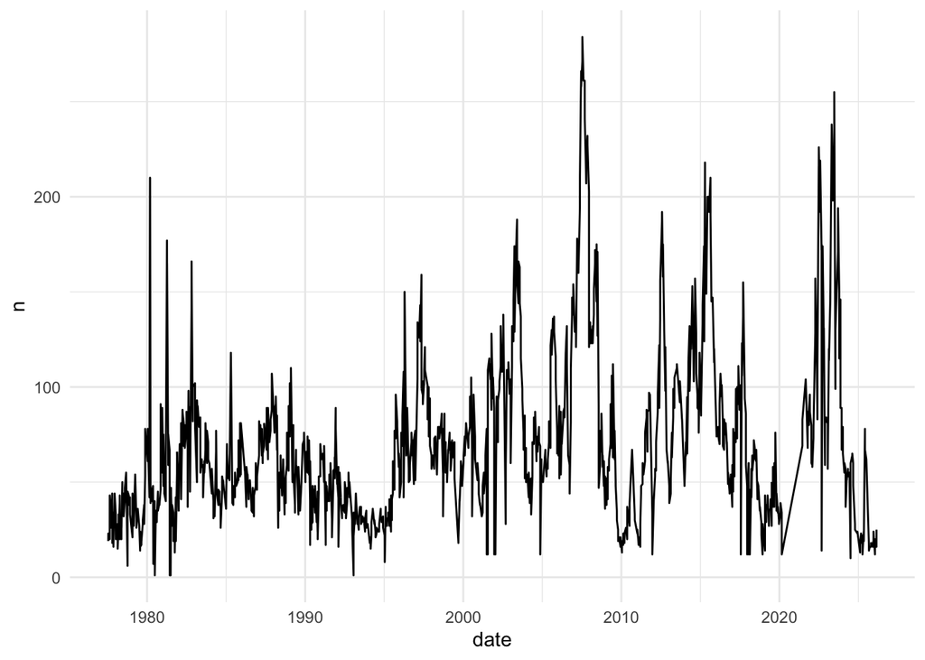

```r
#use count(date) to tally up the number of rodents recorded on each day

portal_rodent_mod |>
  count(date) |>
  ggplot() +
  geom_line(aes(x=date, y=n)) +
  theme_minimal()
```

Use the `floor_date` function to round each date down to the first day of the month, which is great for time series grouping.

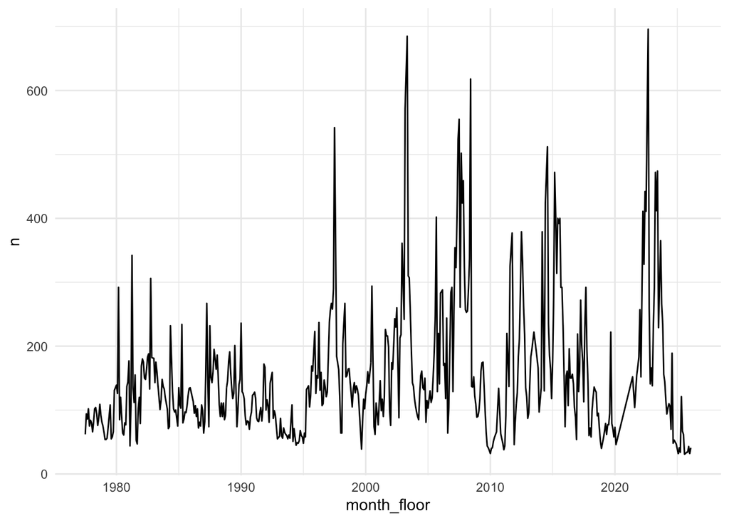

```r
# for floor date you need the date column and the unit which can be week, month, year, etc
# your unit needs to be in quotes (e.g. "month")

portal_rodent_mod |>
  mutate(month_floor = floor_date(date, "month")) |>
  count(month_floor) |>
  ggplot() +
  geom_line(aes(x=month_floor, y=n)) +
  theme_minimal()
```

Alternatively, use the `floor_date` function to round each date down to first day of the year:

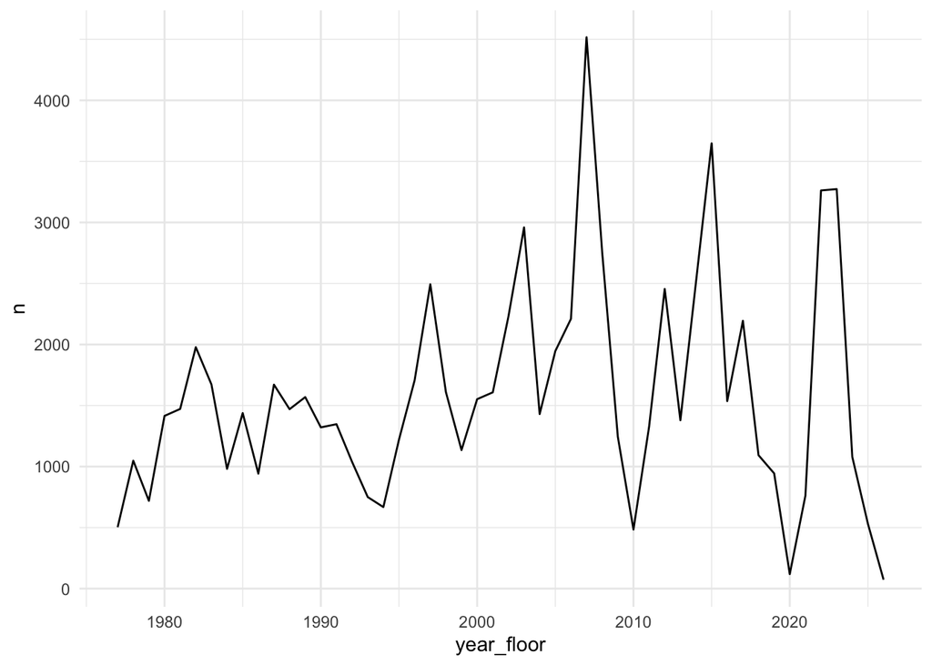

```r
#same plot as above, but for "year"

portal_rodent_mod |>
  mutate(year_floor = floor_date(date, "year")) |>
  count(year_floor) |>
  ggplot() +
  geom_line(aes(x=year_floor, y=n)) +
  theme_minimal()
```

## In groups

Recreate the above daily line plot for 2017 only.

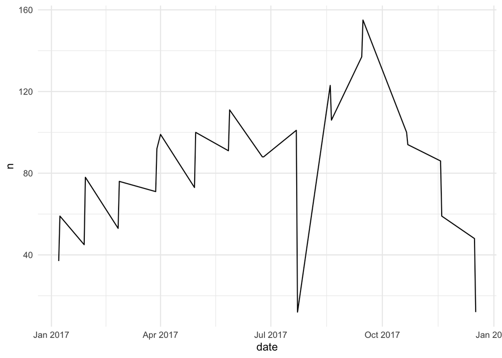

```r
portal_rodent_mod |>
  filter(year==2017) |>
  count(date) |>
  ggplot() +
  geom_line(aes(x=date, y=n)) +
  theme_minimal()
```

Recreate the above line plot March 15 - Dec 31, 2017.

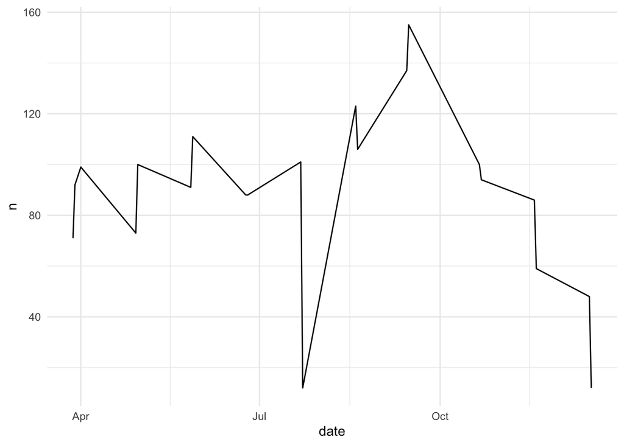

```r
portal_rodent_mod |>
  filter(date > mdy(03152017),
         date < mdy(12312017)) |>
  count(date) |>
  ggplot() +
  geom_line(aes(x=date, y=n)) +
  theme_minimal()
```

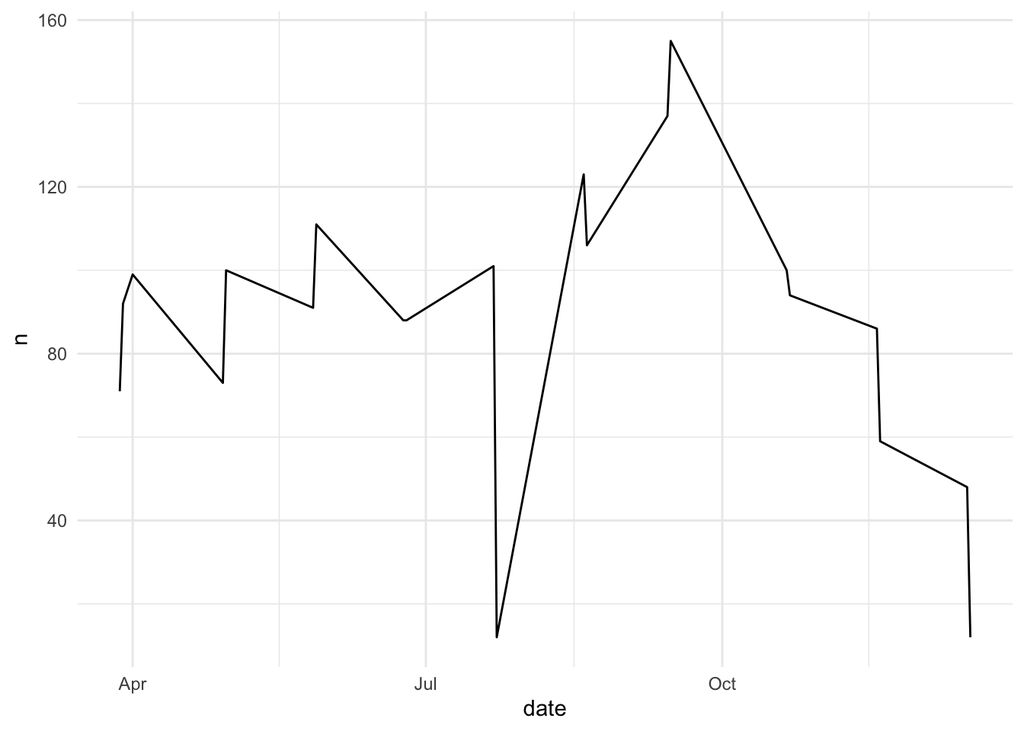

```r
portal_rodent_mod |>
  filter(date > "2017-03-15",
         date < "2017-12-31") |>
  count(date) |>
  ggplot() +
  geom_line(aes(x=date, y=n)) +
  theme_minimal()
```

Determine on which days of the week most rodents are observed (when most sampling happens). *Don’t overthink it.*

```r
portal_rodent_mod |>
  mutate(wday=wday(date, label=TRUE)) |>
  count(wday)
```

```
  wday     n
1  Sun 30364
2  Mon  4765
3  Tue  3886
4  Wed  4220
5  Thu  3959
6  Fri  3725
7  Sat 28367
```

Now turn your day of the week count into a barplot.

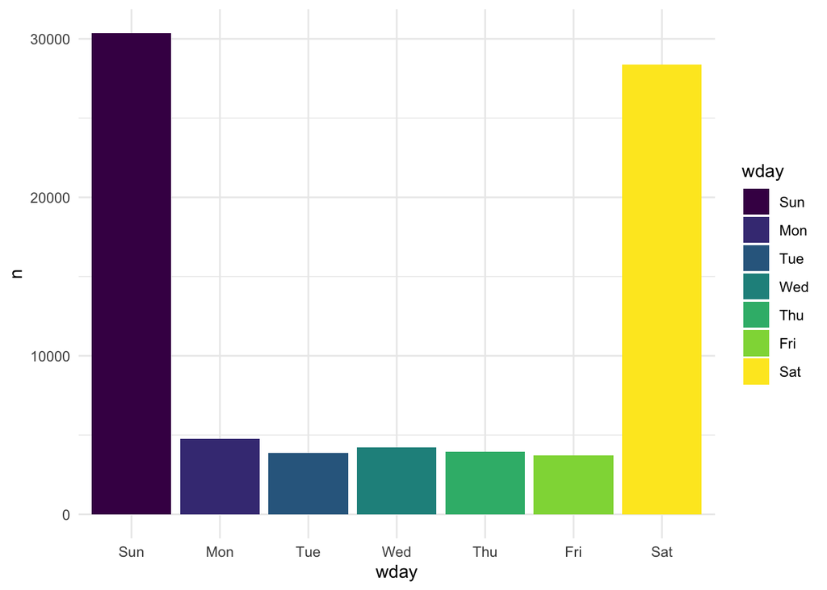

```r
portal_rodent_mod |>
  mutate(wday=wday(date, label=TRUE)) |>
  count(wday) |>
  ggplot() +
  geom_col(aes(x=wday, y=n, fill=wday)) +
  theme_minimal()
```

## Plotly

There really isn’t much to this. Plotly provides a wrapper for existing ggplots.

```r
library(plotly)

#line_graph

linegraph <- portal_rodent_mod |>
  mutate(month_floor = floor_date(date, "month")) |>
  count(month_floor) |>
  ggplot() +
  geom_line(aes(x=month_floor, y=n)) +
  theme_minimal()

#barplot

bar_plot <- portal_rodent_mod |>
  mutate(wday=wday(date, label=TRUE)) |>
  count(wday) |>
  ggplot() +
  geom_col(aes(x=wday, y=n, fill=wday)) +
  theme_minimal()
```

Now let’s translate them to plotly plots.

```r
# use ggplotly(objectname)

ggplotly(bar_plot)
```

[interactive chart not shown]

```r
ggplotly(linegraph)
```

[interactive chart not shown]

```r
# need to use yday(date) to get day of year in order to plot separate years

plot1 <- portal_rodent_mod |>
  mutate(yday = yday(date)) |>
  group_by(year) |>
  count(yday) |>
  ggplot() +
  geom_point(aes(x=yday, y=n, color=year)) +
  theme_minimal()

ggplotly(plot1)
```

[interactive chart not shown]

```r
plot2 <- portal_rodent_mod |>
  mutate(yday = yday(date)) |>
  group_by(year) |>
  count(yday) |>
  ggplot() +
  geom_point(aes(x=yday, y=n, color=factor(year))) +
  theme_minimal()
```

Now let’s play around with some bells and whistles. First let’s add a range slider.

```r
# the code to add a slider: layout(xaxis = list(rangeslider = list(visible = TRUE)))

ggplotly(plot1) |>
  layout(xaxis = list(rangeslider = list(visible = TRUE)))
```

[interactive chart not shown]

```r
ggplotly(plot2) |>
  layout(xaxis = list(rangeslider = list(visible = TRUE)))
```

[interactive chart not shown]

Let’s try it with faceting.

```r
# first filter for years > 2010
# mutate a doy using yday()
# then make the counts


plot3 <- portal_rodent_mod |>
  filter(year > 2010) |>
  mutate(yday = yday(date)) |>
  group_by(year) |>
  count(yday) |>
  ggplot() +
  geom_point(aes(x=yday, y=n, color=factor(year))) +
  facet_wrap(~year) +
  theme_minimal()

ggplotly(plot3)
```

[interactive chart not shown]

In order to make these work you can just render your .qmd to .html as normal and they will just work. If you want to export them as a separate thing, that’s a lot more complicated.